# ADT Lab 12 (10pts)

## Cassandra

Setup Instructions-

- Go to the Astra DB website (https://astra.datastax.com/) and sign up for a free account.
- Click on database and hit Create Database
- Give database name and Keyspace Name

[figure not shown]

- Go to the CQL Console and see if keyspace was created properly by running the command

`DESC KEYSPACES;`

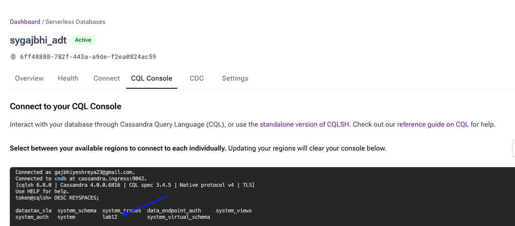

You should see the keyspace that you created earlier. Keyspace is similar to a schema in relational dbms

#### Astra DB

Astra DB is a cloud-native database-as-a-service (DBaaS) offering provided by DataStax, which is designed to provide a fully managed and scalable NoSQL database service for modern applications. Astra DB is built on top of the Apache Cassandra database, but it includes additional features and capabilities that make it easier to use and more powerful.

- Now lets create a people table using this query-

[output not shown]

- Verify if the table is created by running

`DESC TABLES;`

Your output should be like-

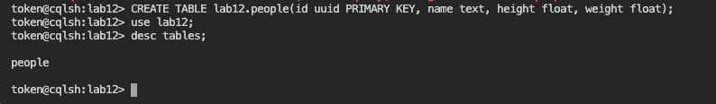

```python
!pip install cassandra-driver
```

```
     ---------------------------------------- 2.9/2.9 MB 18.6 MB/s eta 0:00:00
```

[output not shown]

```python
from cassandra.cluster import Cluster
from cassandra.auth import PlainTextAuthProvider
from cassandra.query import BatchStatement
from uuid import uuid4
import csv
import os
```

- Go to connect tab and download the bundle as shown below

[figure not shown]

```python
# Make sure your current working directory contains the downloaded bundle (secure-connect-sygajbhi-adt.zip)
os.listdir()
```

```
['.ipynb_checkpoints',
 'aaryagar_lab12.ipynb',
 'aaryagar_week10codingpractice.docx',
 'aaryagar_week11codingpractice.docx',
 'aaryagar_week3codingpracticePartA.sql',
 'aaryagar_week3codingpracticePartB.sql',
 'aaryagar_week4codepingpractice_step1.html',
 'aaryagar_week4codepingpractice_step1.ipynb',
 'aaryagar_week4codepingpractice_step1.sql',
 'aaryagar_week4codingpractice2-3.docx',
 'aaryagar_week5codingpractice.docx',
 'aaryagar_week6codingpractice.docx',
 'aaryagar_week7codingpractice.docx',
 'aaryagar_week9codingpractice.docx',
 'ADT_Lab_10-1.ipynb',
 'ADT_Lab_10.html',
 'agarwal_week2_codingpractice.sql',
 'createAnalysisdb.sql',
 'dept.csv',
 'doctors_db.sql',
 'emp.csv',
 'flights_100k.csv',
 'flights_10k.csv',
 'followalongchapter5stats.sql',
 'gpsinfo.csv',
 'HospitalGeneralInformation.csv',
 'movies.csv',
 'ratings.csv',
 'runs.csv',
 'sakila-db',
 'secure-connect-aaryagar-adt.zip',
 'typetest.txt.txt',
 'week1.db',
 'week10_codingpractice_part1_cypher.txt',
 'week2-sqlite-solution.ipynb',
 '~$ryagar_week10codingpractice.docx']
```

- Now again in the connect tab generate and download the token as shown below

[figure not shown]

- Open the token file and put your clientID and secret below

```python
cloud_config= {
  'secure_connect_bundle': 'secure-connect-aaryagar-adt.zip'
}


auth_provider = PlainTextAuthProvider('CiCgidLjJyZZvsxZUSUcINBT', 'iSBRYcfZwp92OyDo82oRl9h,toFMCFZGDZo0d5IbaCwZ4OCcC,lTN2ywvX3xO1WdFGFMs,RIcg9WlBBDEdewtTIfJqpPRrw_UbWtg7tAiGBCrtktJSdLabTim87tsWSl')
cluster = Cluster(cloud=cloud_config, auth_provider=auth_provider)
session = cluster.connect()
```

```python
# Read the data from the CSV file
with open('hw_200-1.csv', 'r') as f:
    reader = csv.reader(f)
    next(reader)
    data = [(uuid4(), row[0], float(row[1]), float(row[2])) for row in reader]
```

```python
data[:10]
```

```
[(UUID('cb06964c-d14f-4210-ad23-f43825dc9493'), '1', 65.78, 112.99),
 (UUID('983b4f55-b2be-40c9-a29a-4eea5e201200'), '2', 71.52, 136.49),
 (UUID('cad3c62c-9138-43de-bf94-03572fb31f98'), '3', 69.4, 153.03),
 (UUID('002d5f88-d8e5-44fd-85de-8303c5298383'), '4', 68.22, 142.34),
 (UUID('be8482cc-b350-44d3-b2bd-74067dbdee31'), '5', 67.79, 144.3),
 (UUID('261d7e2a-0ba4-4106-94fe-c3cbfc1dc0e6'), '6', 68.7, 123.3),
 (UUID('320350a1-5421-4b3b-986c-5d28d634f138'), '7', 69.8, 141.49),
 (UUID('2d4faa57-99d2-4ae9-807d-bde5f07a3db3'), '8', 70.01, 136.46),
 (UUID('d4f3558e-01ca-491f-a66d-1799e61a0d0f'), '9', 67.9, 112.37),
 (UUID('07a22871-1cdf-4a3a-b97b-2570e4f55564'), '10', 66.78, 120.67)]
```

```python
# Set the keyspace
session.set_keyspace('lab12')
```

```python
# Insert the data into the database
query = "INSERT INTO people (id, name, height, weight) VALUES (?, ?, ?, ?)"
prepared = session.prepare(query)
batch = BatchStatement()
for row in data:
    batch.add(prepared, row)
session.execute(batch)
```

```
<cassandra.cluster.ResultSet at 0x1aa3c5957f0>
```

- Now lets go to CQL console and see if values were inserted properly
- Go to CQL console; use lab12 keyspace and run the command-

`SELECT * FROM people;`

- You should see the following

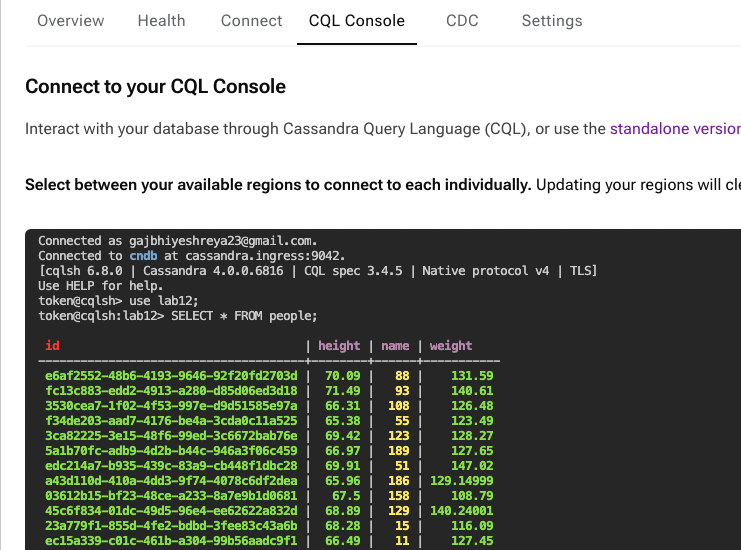

- Now you can run some queries on the people's table

#### 1. Retrieve 10 records from the "people" table

```python
rows = session.execute("SELECT * FROM people limit 10")
for row in rows:
    print(row.id, row.name, row.height, row.weight)
```

```
fbf9bc11-1a07-4ead-bc1f-3c0dea30aca1 14 67.12000274658203 122.45999908447266
8574d2f6-9090-4128-8672-c64ea11d7bce 170 65.98999786376953 111.2699966430664
f1ba8c64-7402-4417-b755-6561343efc20 69 67.22000122070312 103.52999877929688
769f617c-9147-425d-b194-6d3378b2d150 76 66.36000061035156 120.30000305175781
3d38a6ae-e03d-4f6b-a8bf-46c92f05e276 108 66.30999755859375 126.4800033569336
0f375c9d-5e64-4d83-802c-eb5739944586 171 69.43000030517578 122.61000061035156
b5ecee34-b831-449c-9d82-bd82bf5830f9 36 69.20999908447266 128.75
44d95742-6a8c-44c3-a226-29a089fb71e8 33 67.81999969482422 125.79000091552734
7bf2664f-e410-4988-9076-53518ee0e779 57 70.41000366210938 155.89999389648438
432e7625-ff06-4591-8daa-d6b356d0ebff 139 73.9000015258789 151.38999938964844
```

#### 2. Retrieve all data for individuals with a height greater than 70 inches

```python
rows = session.execute("SELECT * FROM people WHERE height > 70")
for row in rows:
    print(row.id, row.name, row.height, row.weight)
```

```
---------------------------------------------------------------------------
InvalidRequest                            Traceback (most recent call last)
~\AppData\Local\Temp\ipykernel_17176\1752905652.py in <module>
----> 1 rows = session.execute("SELECT * FROM people WHERE height > 70")
      2 for row in rows:
      3     print(row.id, row.name, row.height, row.weight)

~\anaconda3\lib\site-packages\cassandra\cluster.cp39-win_amd64.pyd in cassandra.cluster.Session.execute()

~\anaconda3\lib\site-packages\cassandra\cluster.cp39-win_amd64.pyd in cassandra.cluster.ResponseFuture.result()

InvalidRequest: Error from server: code=2200 [Invalid query] message="Cannot execute this query as it might involve data filtering and thus may have unpredictable performance. If you want to execute this query despite the performance unpredictability, use ALLOW FILTERING"
```

- You will get an error here. Now run the below cell

```python
rows = session.execute("SELECT * FROM people WHERE height > 70 allow filtering")
for row in rows:
    print(row.id, row.name, row.height, row.weight)
```

```
7bf2664f-e410-4988-9076-53518ee0e779 57 70.41000366210938 155.89999389648438
432e7625-ff06-4591-8daa-d6b356d0ebff 139 73.9000015258789 151.38999938964844
f3130227-76f9-47af-b24c-ce0cafa9415c 65 70.80999755859375 135.32000732421875
39f5961d-3da5-45ec-ac21-5b05d319e935 83 70.05000305175781 155.3800048828125
9ddcdc02-d7c7-4a0f-b23c-4dd80520b1bc 96 70.55999755859375 131.8000030517578
9cd026a1-e178-4dc2-8df1-7eee03ad16ad 115 70.01000213623047 122.04000091552734
983b4f55-b2be-40c9-a29a-4eea5e201200 2 71.5199966430664 136.49000549316406
2c8660c9-8eca-4537-a5c1-042ca4005091 92 70.23999786376953 141.49000549316406
ed23f88b-c050-41ba-8b31-1afa326af9d5 132 71.2300033569336 130.6999969482422
b325e569-93f9-4cde-b56c-6979f7adb7c2 191 70.19000244140625 144.99000549316406
88bdee9f-4fcd-44dd-8bb7-2fb0aa626fbd 95 70.05999755859375 133.4600067138672
428528c6-7318-4016-9b99-18b019c9f4e4 89 70.18000030517578 121.12000274658203
f681681c-f858-43e0-b3a4-0550d766d2e3 56 70.18000030517578 147.88999938964844
bbd906a8-ca94-4dd7-9a26-385903e066a7 93 71.48999786376953 140.61000061035156
f573084e-cfdc-45f1-83f3-e250a5bb62a8 112 70.05000305175781 127.61000061035156
504714ca-be43-42cf-8c3e-e6e0c34ddf02 113 70.19000244140625 131.63999938964844
2d4faa57-99d2-4ae9-807d-bde5f07a3db3 8 70.01000213623047 136.4600067138672
cca59741-a0cf-4cca-89ba-41af07766ee2 157 70.9800033569336 158.9600067138672
0cccf78b-228b-41ac-85ad-93c42753ea4b 88 70.08999633789062 131.58999633789062
2d430277-c69a-4da6-aef4-de29d2f57b7b 135 71.0999984741211 128.13999938964844
28b751a9-cd86-4125-be2f-5a0cf13b440e 159 72.0199966430664 138.77999877929688
a6dff51c-033c-4fb0-8867-e648b42564cf 34 70.5999984741211 136.22000122070312
c57bd3e9-5239-41ce-8862-5618acf5720d 130 70.23999786376953 133.97999572753906
7328e89e-db8f-41d4-b1b3-2c3d066f2a8e 200 71.38999938964844 127.87999725341797
933a5fb1-93cf-40e7-b3c3-49d443436ab4 155 72.44000244140625 136.74000549316406
aaf8cde7-17a8-4cf1-8d43-68c85035d11c 72 70.83999633789062 134.02000427246094
41b31407-2ec1-4a77-956d-40543da16d87 16 71.08999633789062 140.0
eefab765-1cc8-4f78-bb36-70acdbe58e7d 175 73.83000183105469 139.3000030517578
41053c57-1453-4f22-a01f-ad1da8e61a6b 19 71.2300033569336 137.89999389648438
b49c8fdb-6b39-40ce-a436-cef3f796d18b 35 71.80000305175781 140.10000610351562
d6e8bf85-db8a-471f-98b3-f121e8e06181 53 70.2699966430664 125.4800033569336
5d5ddda9-53e3-4604-81d9-233a1b726beb 27 70.83999633789062 142.4199981689453
```

Why is the query running if we add ALLOW FILTERING at the end?

- ALLOW FILTERING is a way to retrieve data from a table that doesn't involve using the primary key, but it can be an expensive operation as it requires scanning the entire table.
- In general, it's a best practice to avoid using ALLOW FILTERING whenever possible and to design your data model so that queries can be satisfied using the primary key. However, there may be cases where using ALLOW FILTERING is necessary or unavoidable.
1. Similarly now retrive data for individuals with a weight between 150 and 200 pounds

```python
rows = session.execute("SELECT * FROM people WHERE weight > 150 and weight <200 allow filtering")
for row in rows:
    print(row.id, row.name, row.height, row.weight)
```

```
7bf2664f-e410-4988-9076-53518ee0e779 57 70.41000366210938 155.89999389648438
432e7625-ff06-4591-8daa-d6b356d0ebff 139 73.9000015258789 151.38999938964844
39f5961d-3da5-45ec-ac21-5b05d319e935 83 70.05000305175781 155.3800048828125
cca59741-a0cf-4cca-89ba-41af07766ee2 157 70.9800033569336 158.9600067138672
cad3c62c-9138-43de-bf94-03572fb31f98 3 69.4000015258789 153.02999877929688
```

Hint- Use allow filtering; Syntax will be similiar to normal SQL. We are actually using CQL here which is a subset of SQL

Expected output

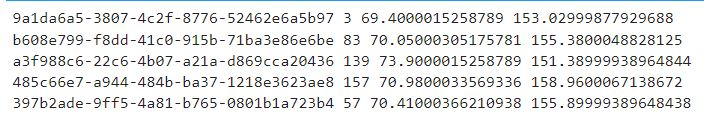